# Coronavirus Analysis of Zimbabwe

K.D.welagamage

10/2/2022

## Introduction

Corona viruses are a large family of viruses that are known to cause illness ranging from the common cold to more serve diseases.Coronavirus disease (COVID-19) is an infectious disease caused by the SARS-CoV-2 virus.A novel coronavirus(COVID-19) was identified in 2019 in Wuhan,China.In March 2020,the World Health Organization(WHO) declared the corona virus outbreak a pandemic.This pandemic has affected millions of people,who are either sick or are being killed due to the spread of this disease.COVID-19 is a new virus that is impacting the whole world badly as i is spreading primarily through contact with the person.It is spread from person to person among those in close contact within 6 feet.

## COVID-19 in Zimbabwe

Zimbabwe,officially Republic of Zimbabwe is a landlocked country in South-Central Africa bordering the countries of Botswana,Mozambique,South Africa and Zambia covering a total of 390,580 square kilometers.It lies between the latitudes of 15.37 and 22.24 degrees south and longitudes of 25.14 and 33.04 degrees east.The capital and largest city is Harare.A country of roughly 15 million people.It was once referred to as the “Jewel of Africa” for its great prosperity during the early years.Zimbabwe lies almost entirely over 1000 feet(300 meters) above sea level.The geography of Zimbabwe is mostly high plateau and mountains in the east. Zimbabwe’s estimated population in 2020 was 14,862,924 with a population density of 38 people per square kilometer.The country’s median age is approximately 18.7 years.According to the 2017 ZimStat report,40% of the population is under 15 years and about 6% are over the age of 65,while less than 1% is above 70 years.Zimbabwe,like most countries worldwide,adopted tough measures to limit widespread importation and local transmission of SARS-CoV-19.Zimbabwe reported its first case of coronavirus disease on 20 march 2020.The first wave of outbreak in the country which started with the first reported case saw over 8000 cases by the end of October 2020,with 243 Covid-19 related deaths.The government of Zimbabwe launched the Covid-19 National Preparedness and Response Plan in March 2020 and subsequently declared a state of disaster.

## Location of Zimbabwe

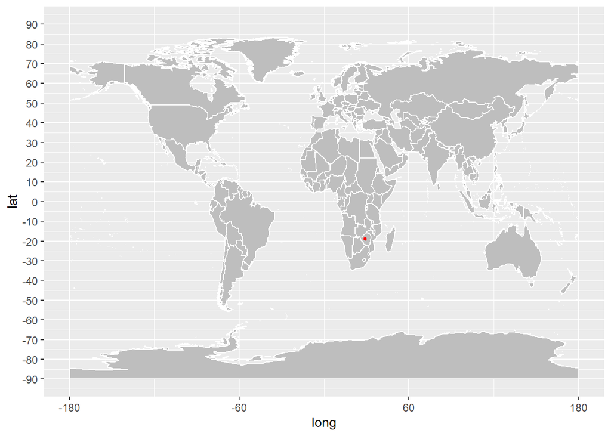

## Exploratory data analysis

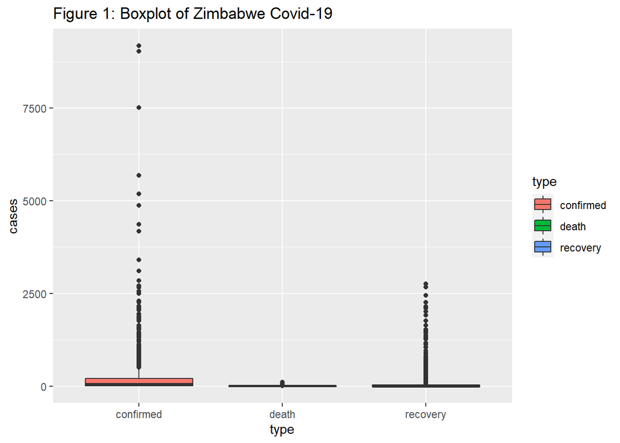

## Summary of Coronavirus in Zimbabwe

```
##       date              province           country               lat
##  Min.   :2020-01-22   Length:2652        Length:2652        Min.   :-19.02
##  1st Qu.:2020-08-29   Class :character   Class :character   1st Qu.:-19.02
##  Median :2021-04-07   Mode  :character   Mode  :character   Median :-19.02
##  Mean   :2021-04-07                                         Mean   :-19.02
##  3rd Qu.:2021-11-14                                         3rd Qu.:-19.02
##  Max.   :2022-06-23                                         Max.   :-19.02
##
##       long           type               cases              uid
##  Min.   :29.15   Length:2652        Min.   :   0.00   Min.   :716
##  1st Qu.:29.15   Class :character   1st Qu.:   0.00   1st Qu.:716
##  Median :29.15   Mode  :character   Median :   3.50   Median :716
##  Mean   :29.15                      Mean   : 129.69   Mean   :716
##  3rd Qu.:29.15                      3rd Qu.:  47.75   3rd Qu.:716
##  Max.   :29.15                      Max.   :9185.00   Max.   :716
##                                     NA's   :2
##      iso2               iso3               code3     combined_key
##  Length:2652        Length:2652        Min.   :716   Length:2652
##  Class :character   Class :character   1st Qu.:716   Class :character
##  Mode  :character   Mode  :character   Median :716   Mode  :character
##                                        Mean   :716
##                                        3rd Qu.:716
##                                        Max.   :716
##
##    population       continent_name     continent_code
##  Min.   :14862927   Length:2652        Length:2652
##  1st Qu.:14862927   Class :character   Class :character
##  Median :14862927   Mode  :character   Mode  :character
##  Mean   :14862927
##  3rd Qu.:14862927
##  Max.   :14862927
##
```

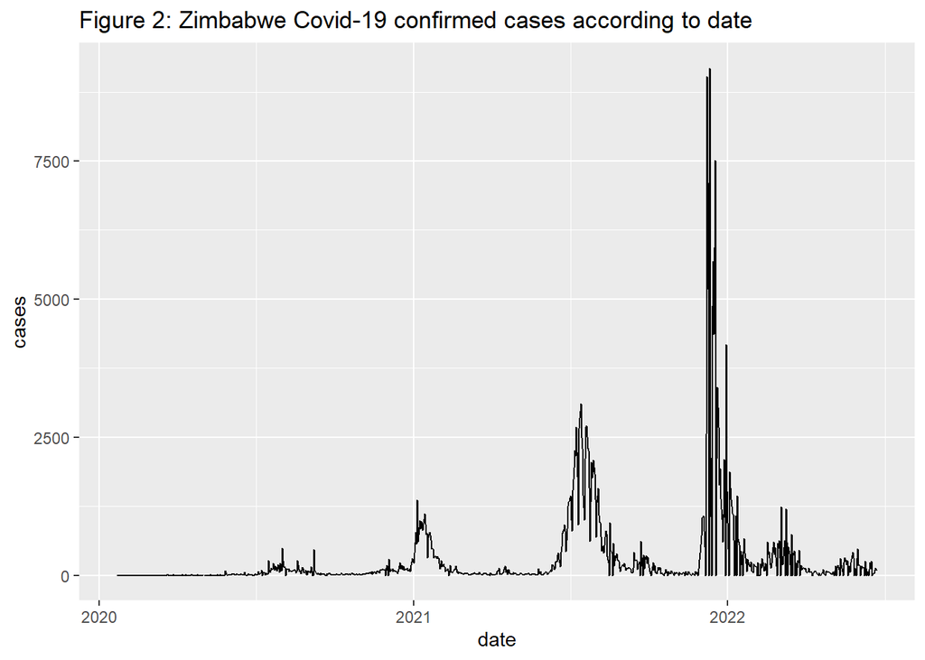

According to the figure 2,Covid-19 cases have been reported more and more in the early days of 2022.

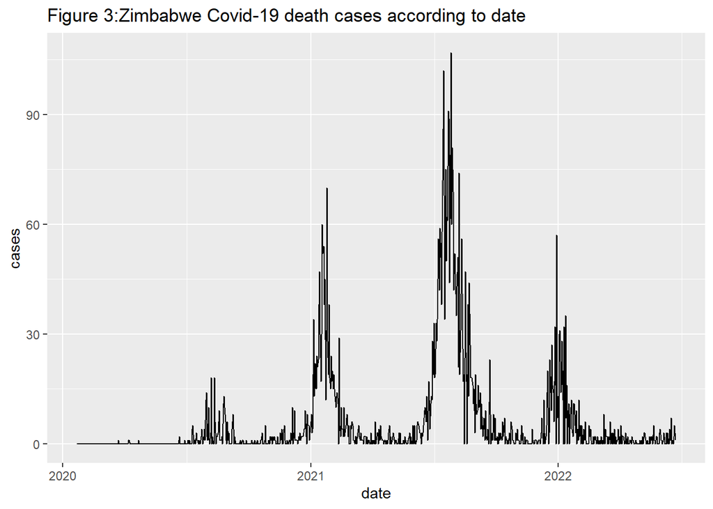

According to the figure 3,the highest number of death cases were reported in the middle months of 2021,while early 2021 and early 2022 showed a relative increase.

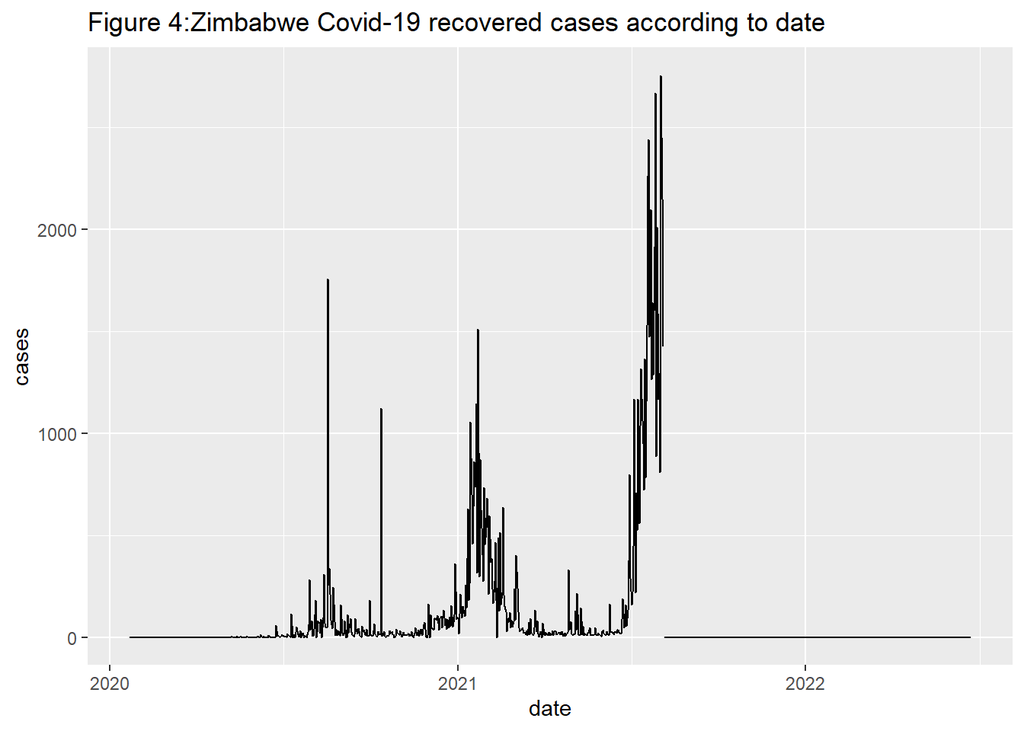

```
## [1] 562
```

```
## [1] 884
```

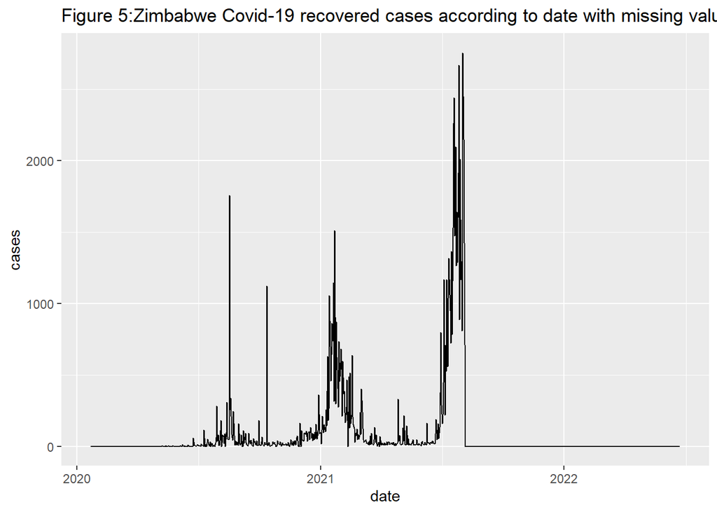

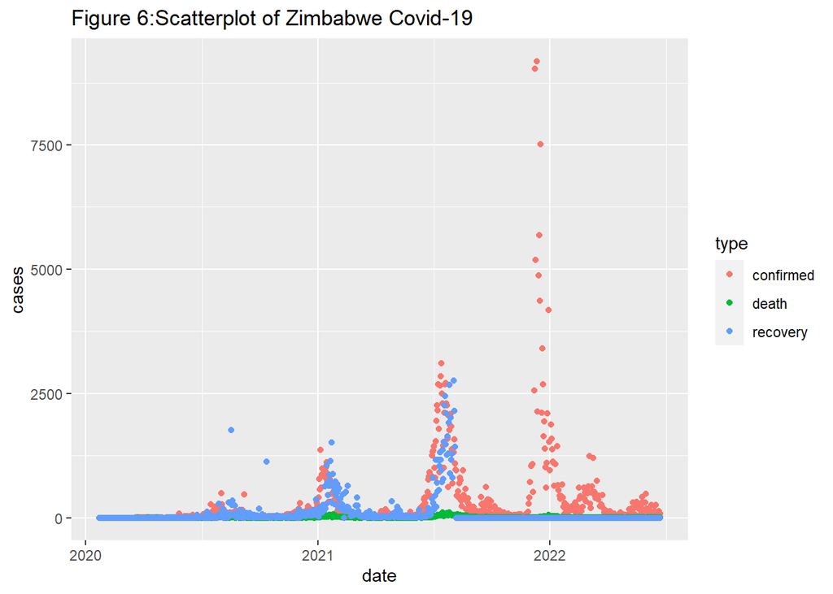

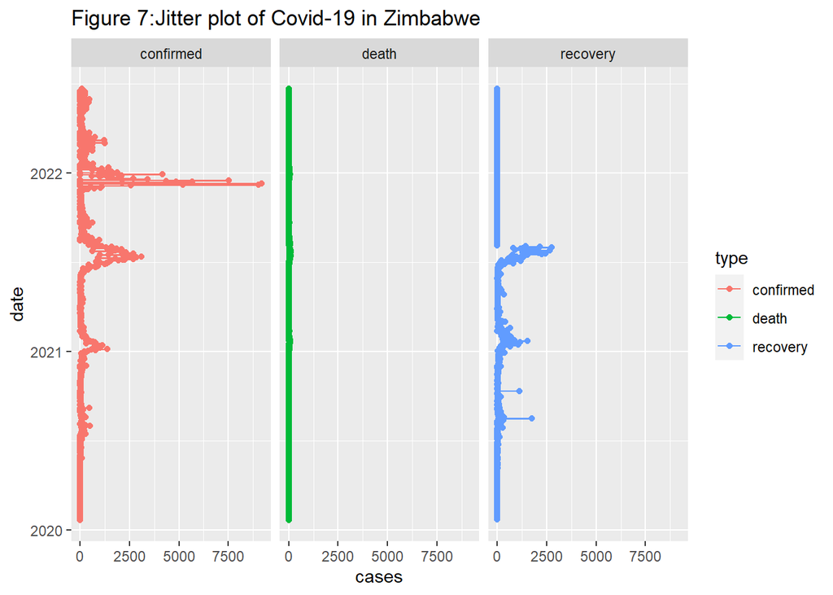

According to the figure 6 and 7,shows that the number of death cases is low compared to the confirmed cases.

```
##           date province  country       lat     long      type cases uid iso2
## 690 2021-12-11     <NA> Zimbabwe -19.01544 29.15486 confirmed  9185 716   ZW
##     iso3 code3 combined_key population continent_name continent_code
## 690  ZWE   716     Zimbabwe   14862927         Africa             AF
```

```
##           date province  country       lat     long  type cases uid iso2 iso3
## 553 2021-07-27     <NA> Zimbabwe -19.01544 29.15486 death   107 716   ZW  ZWE
##     code3 combined_key population continent_name continent_code
## 553   716     Zimbabwe   14862927         Africa             AF
```

According to table,the highest number of corona patients have been reported on 11-12-2021 and the highest number of deaths have been reported on 27-07-2021.

## Comparison with other countries

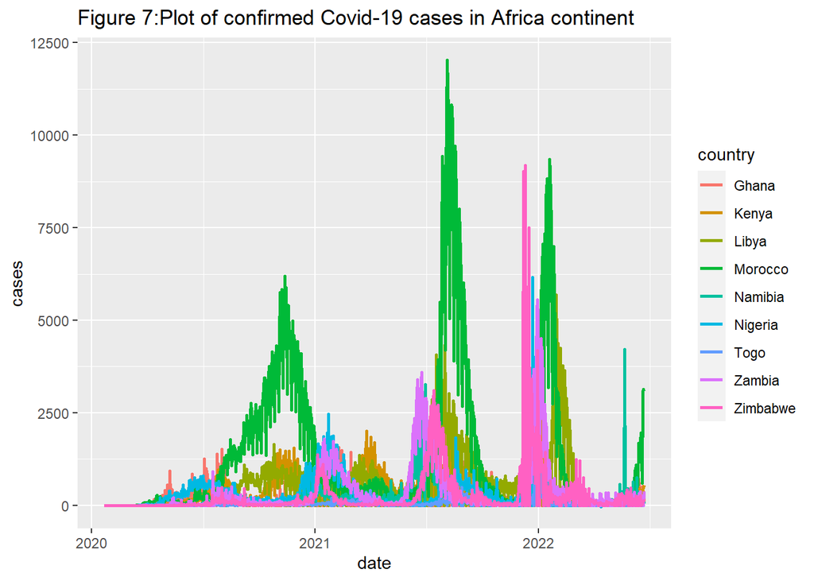

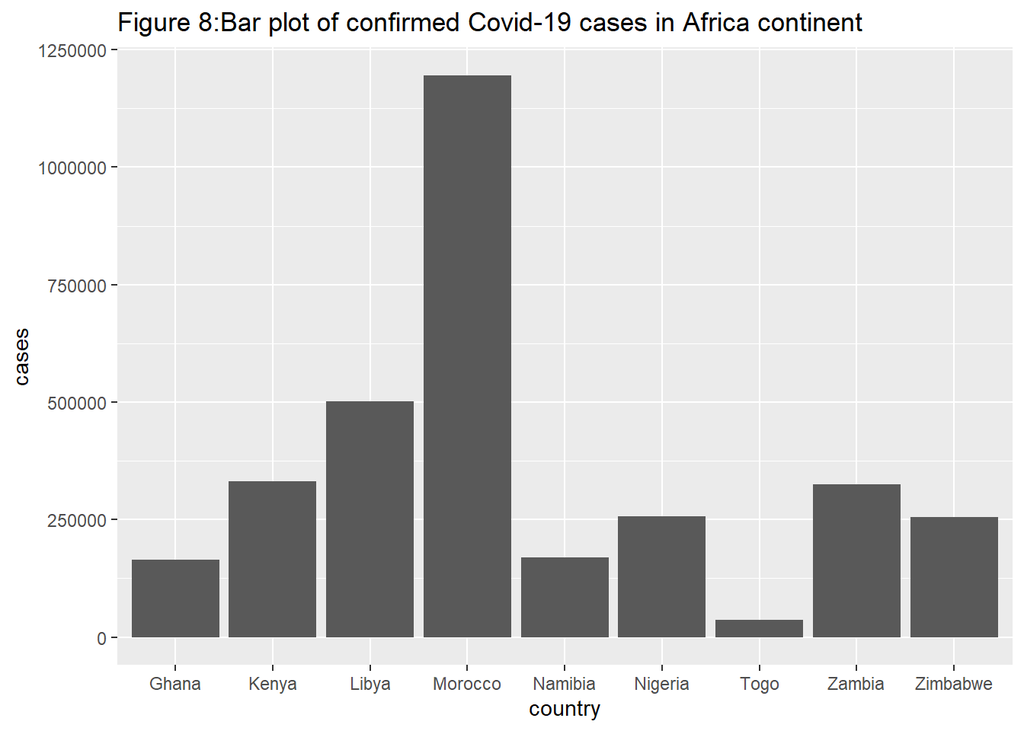

According to the figure 8,Morocco has reported the highest number of Covid-19 cases ,while Togo has reported the lowest.Zimbabwe has reported less number of Covid-19 cases compared to morocco.Almost the same number of Covid-19 cases have been reported from Zimbabwe and Nigeria.

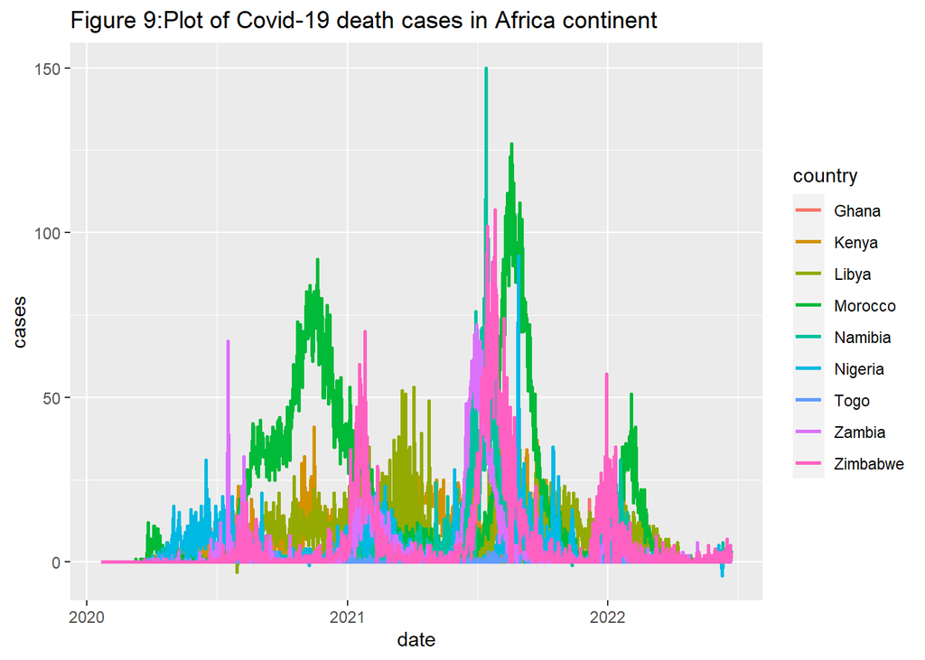

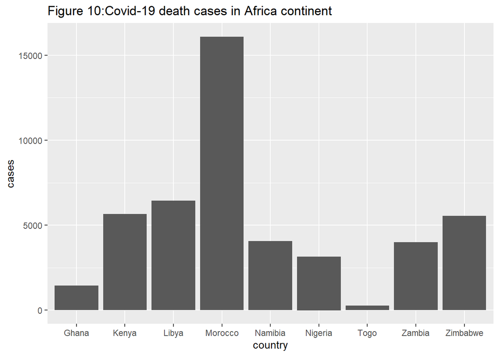

According to the figure 10,Morocco has reported the highest number of Covid-19 death cases ,while Togo has reported the lowest.Morocco has recorded almost three times as many deaths as Zimbabwe.

```
##        type    n
## 1 confirmed 7956
## 2     death 7956
## 3  recovery 7956
```

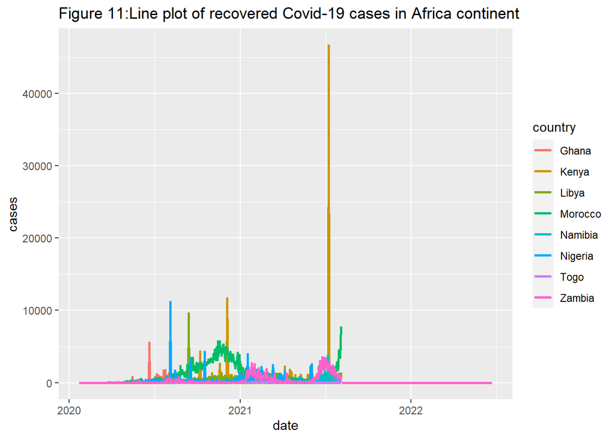

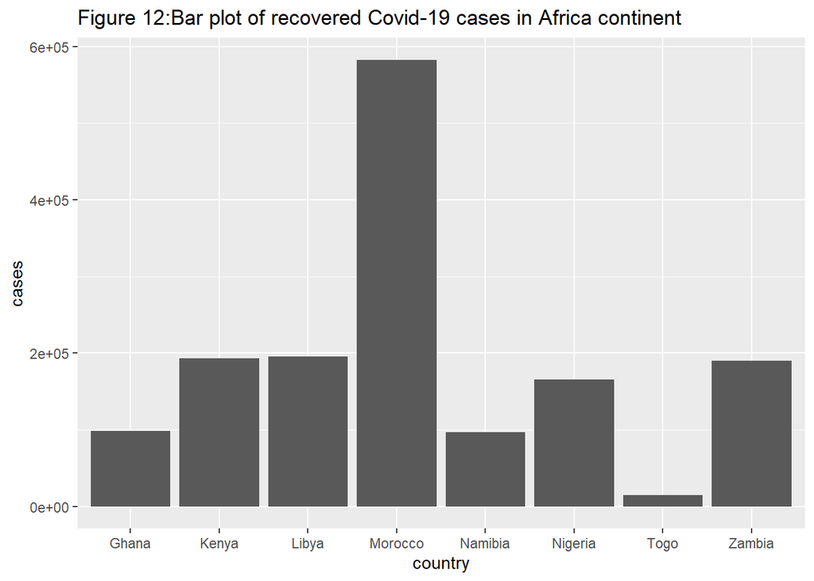

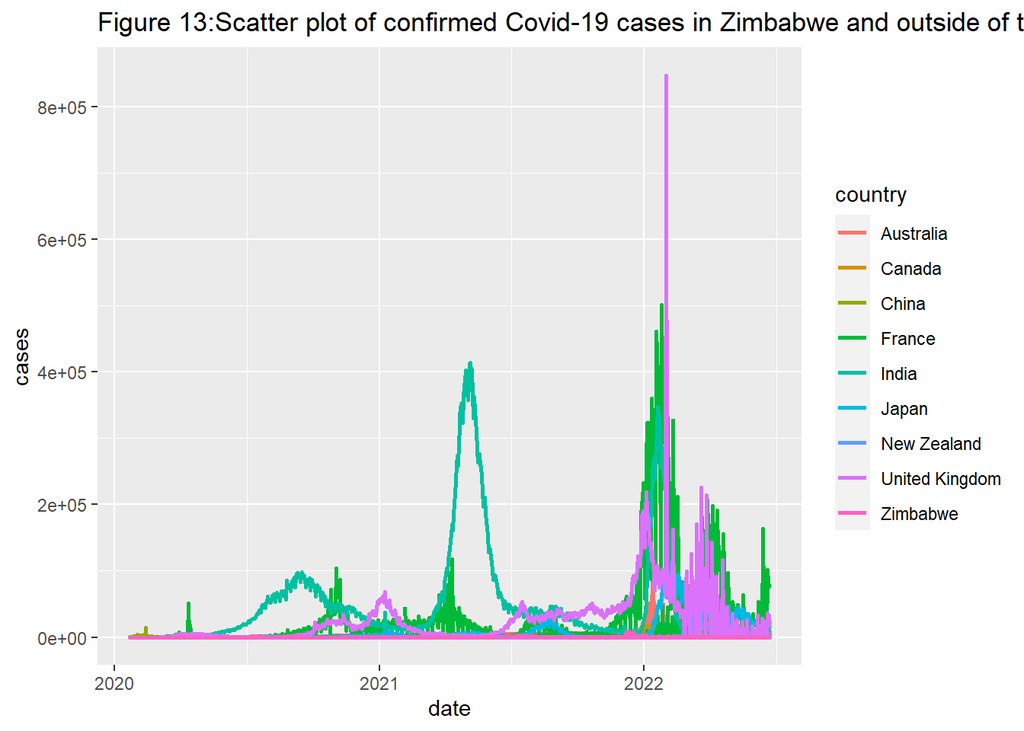

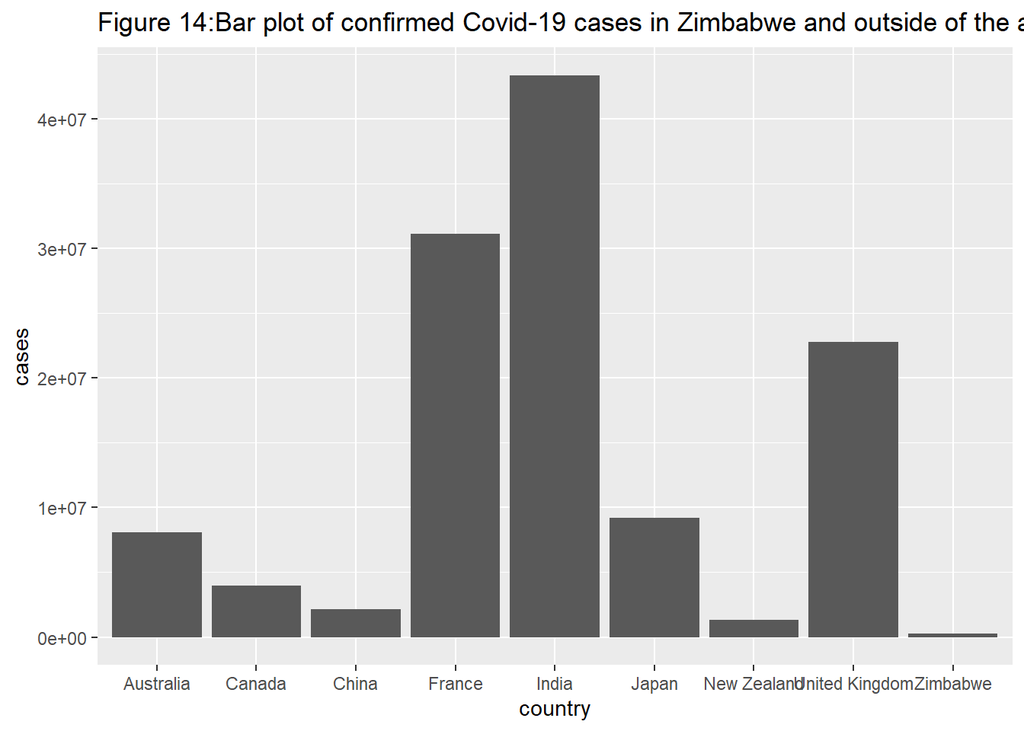

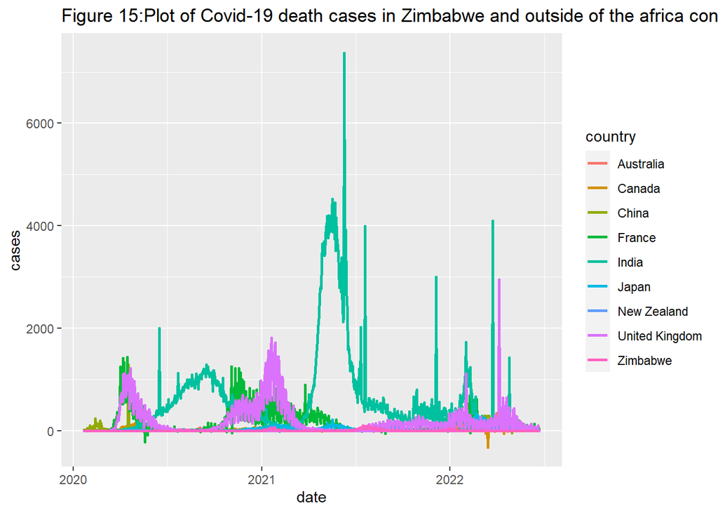

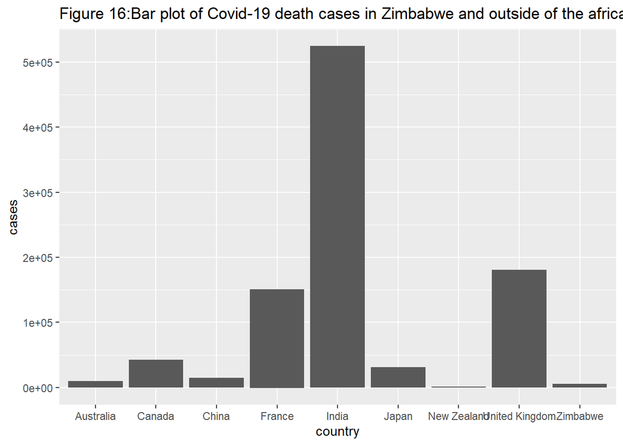

## References

Chitungo,I.;Dzinamarira,T.;Tunguwarara,N.;Chimene,Mukwenha,s.;Kunongu,E.;Musuku,G.;Murewanhema,G.COVID-19 Response in zimbabwe:The need for a paradigm shift? COVID 2022,2(7),895-906. https://doi.org/10.3390/covid2070065

Mutanda D,cogent Soc. Sci.,2022,Challenges and oppurtunities for Zimbabwe’s response to COVID-19. http://www.tandfonline.com/doi/full/

Msu-Ibc A,Us C,Zimbabwe:Introduction https://globaledge.msu.edu/countries/zimbabwe